# Project 1 - CPU Monitoring (Linux)

# 1 Objectives

- Offer an introduction to Performance Monitoring
- Present the main CPU metrics and how to interpret them
- Get you to use various tools for monitoring the performance of the CPU
- Familiarize you with the x86 Hardware Performance Counters
- Learn how to optimise a program using a variety of techniques based on profiling data.

# 2 Proof of Work

Before you start, create a document file. Here, you will add screenshots / code snippets / comments for each exercise. Whatever you decide to include, it must prove that you managed to solve the given task (so don’t show just the output, but how you obtained it and what conclusion can be drawn from it).

# 3 Introduction

## 3.1 Performance Monitoring

Performance monitoring is the process of regularly checking a set of metrics and tracking the overall health of a specific system. Monitoring is tightly coupled with performance tuning, and a Linux system administrator should be proficient in these two subjects, as one of their main responsibilities is to identify bottlenecks and find solutions to help the operating system surpass them. Pinpointing a Linux system bottleneck requires a deep understanding of how various components of this operating system work (e.g. how processes are scheduled on the CPU, how memory is managed , the way that I/O interrupts are handled, the details of network layer implementation, etc). From a high level, the main subsystems that you should think of when tuning are CPU, Memory, I/O and Network.

These four subsystems are vastly depending on each other and tuning the whole system implies keeping them in harmony. To quote a famous idiom, “a chain is no stronger than its weakest link”. Thus, when investigating a system performance issue, all the subsystems must be checked and analysed.

Being able to discover the bottleneck in a system requires also understanding of what types of processes are running on it. The application stack of a system can be broken down in two categories:

- CPU Bound - performance is limited by the CPU
  - Requires heavy use of the CPU (e.g. for batch processing, mathematical operations, etc)
  - e.g. High volume web servers
- I/O Bound - performance is limited by the I/O subsystem
  - Requires heavy use of memory and storage system
  - An I/O Bound application is usually processing large amounts of data
  - An often behaviour is to use CPU resources for making I/O requests and to enter a sleeping state
  - e.g. Database applications

Before going further with the CPU specific metrics and tools, here is a methodical approach which can guide you when tuning the performance of a system:

- Understand the factors which affect the performance
- Create a baseline measurement with the normal performance of the system
- Reproduce the issue and compare the measurements with the baseline to narrow down the bottleneck to a specific subsystem
- Try a single change at a time and test the results

## 3.2 Introducing the CPU and CPU Metrics

Before looking at the numerous performance measurement tools present in the Linux operating system, it is important to understand some key concepts and metrics, along with their interpretation regarding the performance of the system.

The kernel contains a scheduler which is in charge of scheduling two types of resources: interrupts and threads. The resources are assigned by the scheduler with different priorities. The following list presents the priorities:

- User Processes - All the processes running in the user space - having the lowest priority in the scheduling mechanism
- System Processes - All kernel processing
- Interrupts - Devices announcing the kernel that they are done processing

### 3.2.1 Context Switches

While executing a process, the necessary set of data is stored in registers on the processor and cache. This group of information is called a context. Each thread owns an allotted time quantum to spend on the CPU, and when the time finishes or it is preempted by a higher priority task, a new ready to run process will be scheduled. When the next process is scheduled to run, the context of the current will be stored and the context of the new one is restored to the registers, this process being named context switch. Having a great volume of context switching is not desired because the CPU has to flush its register and cache each time, to gain room for the new process, which leads to performance issues.

### 3.2.2 The Run Queue

Each CPU preserves its own run queue of threads. In an ideal scenario, the scheduler would be constantly executing threads. Threads can be in different states: runnable - processes which are ready to be executed or in a sleep state - being blocked while waiting for I/O. If the system has performance issues or it’s overloaded, then the queue starts to fill up and a process thread will take longer to execute.

The same concept is known also as “load”. This term is measured by load average, which is a rolling average of the sum of the processes waiting to be processed and the processes waiting for uninterruptible task to be completed. Unix systems traditionally present the CPU load as 1-minute, 5-minute and 15-minute averages.

### 3.2.3 CPU Utilisation

The CPU Utilisation is a meaningful metric to observe how the running processes make use of the given processing resources. You can find the following categories the vast majority of performance monitoring tools:

- User time - the time percentage a CPU spends on user processes
  - High user time values are recommended because this usually means that the system carries out actual work
- System time - the time percentage a CPU spends on kernel threads and interrupts
  - High system time values could mean bottlenecks in the network and driver stack
- Waiting I/O - the time percentage a CPU waits for a I/O event to occur
  - A system should not spend too much time waiting for I/O operations
- Idle time - the time percentage a CPU spends waiting for tasks
- Nice time - the time percentage spends on changing the priority and execution order of processes. It is often included in the user time

## 3.3 CPU Performance Monitoring

The Linux distributions have various monitoring tools available. Some of the utilities deal with metrics in a single tool, providing well formatted output which eases the understanding of the system performance. Other tools are specialized on more specific metrics and give us detailed information.

Some of the most important Linux CPU performance monitoring tools:

| Tool | Most useful function |
| --- | --- |
| vmstat | System activity |
| top | Process activity |
| uptime, w | Average system load |
| ps, pstree | Displays the processes |
| iostat | Average CPU load |
| sar | Collect and report system activity |
| mpstat | Multiprocessor usage |

## 3.4 Examples

Understanding how well a CPU is performing is a matter of interpreting the run queue, its utilisation, and the amount of context switching performed. Although performance is relative to baseline statistics, in the absence of these statistics, the following general performance expectations of a system can be used as a guideline:

- Run Queues – A run queue should not have more than 3 threads queued per processor. For example, a dual processor system should not have more than 6 threads in the run queue.
- CPU Utilisation – A fully utilised CPU should have the following utilisation distribution:
  - 65% – 70% User Time
  - 30% – 35% System Time
  - 0% – 5% Idle Time
- Context Switches – The amount of context switches is directly relevant to CPU utilisation. As long as the CPU sustains the previously presented utilisation distribution, it is acceptable to have a high amount of context switches.

The following two examples give interpretations of the outputs generated by **vmstat**.

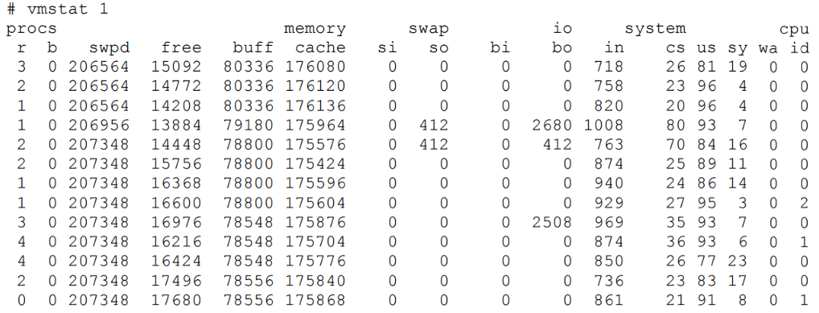

### 3.4.1 Example A - Sustained CPU Utilisation

[figure not shown]

### 3.4.2 Example B - Overloaded Scheduler

The following observations can be made based on this output:

- The amount of context switches is higher than interrupts, suggesting that the kernel has to spend a considerable amount of time context switching threads.
- The high volume of context switches is causing an unhealthy balance of CPU utilisation. This is evident by the fact that the wait on IO percentage is extremely high and the user percentage is extremely low.
- Because the CPU is blocked waiting for I/O, the run queue starts to fill and the amount of threads blocked waiting on I/O also fills.

*These examples are from Darren Hoch’s Linux System and Performance Monitoring.*

# 4 Tasks

## 4.1 Vmstat

The **vmstat** utility provides a good low-overhead view of system performance. Since **vmstat** is such a low-overhead tool, it is practical to have it running even on heavily loaded servers when it is needed to monitor the system’s health.

### 4.1.1 Task A - Monitoring stress

Run **vmstat** on your machine with a 1 second delay between updates. Notice the CPU utilisation (info about the output columns [here](https://medium.com/@damianmyerscough/vmstat-explained-83b3e87493b3)).

In another terminal, use the **stress** command to start N CPU workers, where N is the number of cores on your system. Do not pass the number directly. In stead, use command substitution.

### 4.1.2 Task B - How does it work?

Let us look at how **vmstat** works under the hood. We can assume that all these statistics (memory, swap, etc.) can not be normally gathered in userspace. So how does **vmstat** get these values from the kernel? Or rather, how does any process interact with the kernel? Most obvious answer: **system calls**.

```
$ strace vmstat
```

*“All well and good. But what am I looking at?”*

What you *should* be looking at are the system calls after the two **write**s that display the output header (hint: it has to do with **/proc/** file system). So, what are these files that **vmstat** opens?

```
$ file /proc/meminfo
$ cat /proc/meminfo

$ man 5 proc
```

The manual should contain enough information about what these kernel interfaces can provide. However, if you are interested in *how* the kernel generates the statistics in **/proc/meminfo** (for example), a good place to start would be meminfo.c.

### 4.1.3 Task C - USO flashbacks (1)

Write a one-liner that uses **vmstat** to report complete **disk statistics** and sort the output in **descending** order based on **total reads** column.

You can eliminate the first two header lines from the **vmstat** output using `tail -n +3`.

## 4.2 Mpstat

Open [fact_rcrs.zip](https://drive.google.com/file/d/1m5bRwa4i9xJ4Tgb3rJWCCs5rCuLO5emN/view?usp=sharing) and look at the code.

### 4.2.1 Task A - Python recursion depth

Try to run the script while passing 1000 as a command line argument. Why does it crash?

Luckily, python allows you to both retrieve the current recursion limit *and* set a new value for it. Increase the recursion limit so that the process will never crash, regardless of input (assume that it still has a reasonable upper bound).

### 4.2.2 Task B - CPU affinity

Run the script again, this time passing 10000. Use **mpstat** to monitor the load on each *individual* CPU at 1s intervals. The one with close to 100% load will be the one running our script. Note that the process might be passed around from one core to another.

Stop the process. Use **stress** to create N-1 CPU workers, where N is the number of cores on your system. Use **taskset** to set the CPU affinity of the N-1 workers to CPUs 1-(N-1) and then run the script again. You should notice that the process is scheduled on cpu0.

**Note**: to get the best performance when running a process, make sure that it stays on the same core for as long as possible. Don’t let the scheduler decide this for you, if you can help it. Allowing it to bounce your process between cores can drastically impact the efficient use of the cache and the TLB. This holds especially true when you are working with servers rather than your personal PCs. While the problem may not manifest on a system with only 4 cores, you can’t guarantee that it also won’t manifest on one with 40 cores. When running several experiments in parallel, aim for something like this:

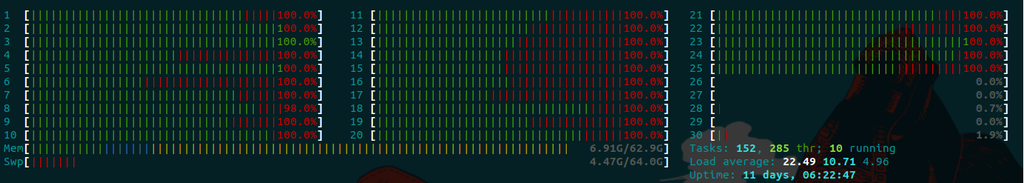

**Figure above:** **htop** output. Processes are bound to specific cores, increasing performance by not potentially invalidating L1 and L2 caches. This works out well since we have fewer active processes than available cores. Otherwise, setting the affinity to a single core may backfire; the rescheduling of these processes could be delayed until other processes are also allocated a time slice. We notice that CPU usage on these cores is maxed (green:user space, red:kernel space). The ratio tells us that a considerable amount of time is spent in kernel space, leading us to believe that the processes are I/O bound.

### 4.2.3 Task C - USO flashbacks (2)

Write a bash command that binds CPU **stress** workers on your odd-numbered cores (i.e.: 1,3,5,…). The list of cores and the number of stress workers must NOT be hardcoded, but constructed based on **nproc** (or whatever else you fancy).  
In your submission, include both the bash command and a **mpstat** capture to prove that the command is working.

## 4.3 Zip with compression levels

The **zip** command is used for compression and file packaging under Linux/Unix operating system. It provides 10 levels of compression, where:

- **level 0** : provides no compression, only packaging
- **level 6** : used as default compression level
- **level 9** : provides maximum compression

```
$ zip -5 file.zip file.txt
```

### 4.3.1 Task A - Measurements

Write a script to measure the compression rate and the time required for each level. Use the following files:

- two largest bitmaps from [here](https://www.fileformat.info/format/bmp/sample/index.htm)
- this large text file [here](https://norvig.com/big.txt)

### 4.3.2 Task B - Plot

Fill the data you obtained into the **python3** script in [plot.zip](https://drive.google.com/file/d/1pQtcOymnRiMFiT_bh0tZi31iHW0aSesp/view?usp=sharing).  
Make sure you have **python3** and **python3-matplotlib** installed.

## 4.4 Hardware counters

A significant portion of the system statistics that can be generated involve hardware counters. As the name implies, these are special registers that count the number of occurrences of specific events in the CPU. These counters are implemented through **Model Specific Registers** (MSR), control registers used by developers for debugging, tracing, monitoring, etc. Since these registers may be subject to changes from one iteration of a microarchitecture to the next, we will need to consult chapters 18 and 19 from [Intel 64 and IA-32 Architectures Developer’s Manual: Vol. 3B](https://www.intel.com/content/www/us/en/architecture-and-technology/64-ia-32-architectures-software-developer-vol-3b-part-2-manual.html).

The instructions that are used to interact with these counters are [RDMSR](https://www.felixcloutier.com/x86/rdmsr), [WRMSR](https://www.felixcloutier.com/x86/wrmsr) and [RDPMC](https://www.felixcloutier.com/x86/rdpmc). Normally, these are considered privileged instruction (that can be executed only in ring0, aka. kernel space). As a result, acquiring this information from ring3 (user space) requires a context switch into ring0, which is a costly operation. The objective of this task is to prove that this is not necessarily the case and that it is possible to configure and examine these counters from ring3 in as few as a couple of clock cycles.

Before getting started, one thing to note is that there are two types of performance counters:

1. Fixed Function Counters
   - each can monitor a single, distinct and predetermined event (burned in hardware)
   - are configured a bit differently than the other type
   - are not of interest to us in this laboratory
2. General Purpose Counters
   - can be configured to monitor a specific event from a list of over 200 (see chapters 19.1 and 19.2)

Download [hw_counter.zip](https://drive.google.com/file/d/11ei0N7GRPzOJfXorw1RV-PHfyjpPPs4S/view?usp=sharing).

Here is an overview of the following five tasks:

- **Task A**: check the version ID of your CPU to determine what it’s capable of monitoring.
- **Task B**: set a certain bit in CR4 to enable ring3 usage of the RDPMC instruction.
- **Task C**: use some ring3 tools to enable the hardware counters.
- **Task D**: start counting L2 cache misses.
- **Task E**: use RDPMC to measure the cache misses for a familiar program.

### 4.4.1 Task A - Hardware Info

First of all, we need to know what we are working with. Namely, the microarchitecture *version ID* and the *number of counters* per core. To this end, we will use cpuid (basically a wrapper over the [CPUID](https://www.felixcloutier.com/x86/cpuid) instruction.) All the information that we need will be contained in the 0AH leaf (might want to get the raw output of **cpuid**):

- **CPUID.0AH:EAX[15:8]** : number of general purpose counters
- **CPUID.0AH:EAX[7:0]** : version ID
- **CPUID.0AH:EDX[7:0]** : number of fixed function counters

Note: the first two columns of the output represent the EAX and ECX registers used when calling CPUID. If the most significant bit in EAX is 1 (i.e.: starts with 0x8) the output is for extended options. ECX is a relatively new addition. So when looking for the 0AH leaf, search for a line starting with **0x0000000a**. The register contents following ‘:’ represent the output of the instruction.

Point out which is which in the **cpuid** output.

### 4.4.2 Task B - Unlock RDPMC in ring3

This is pretty straightforward. All you need to do is set the **Performance-Monitor Counter Enable** bit in CR4. Naturally, this can’t be done from ring3. As such, we provide a kernel module that does it for you (see *hack_cr4.c*.) When the module is loaded, it will set the aforementioned bit. Similarly, when the module is unloaded, it will revert the change. Try compiling the module, loading and unloading it and finally, check the kernel message log to verify that it works.

If you get errors during compilation, try using gcc version 7.5.0.

```
$ make
$ sudo insmod hack_cr4.ko
$ sudo rmmod hack_cr4
$ dmesg
```

Note: the module must remain loaded in the kernel in order to keep the bit set. If during Task E you get a segfault, the reason is that you (probably) unloaded the module and you no longer have permission to run the instruction in ring3. This does NOT invalidate your work in Tasks C and D; simply load the module once more.

### 4.4.3 Task C - Configure IA32_PERF_GLOBAL_CTRL

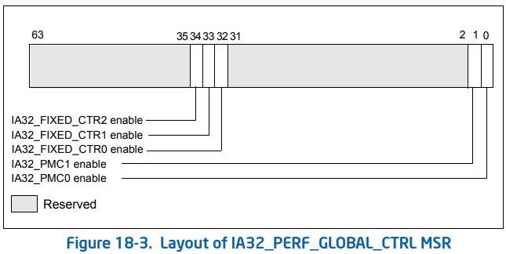

**Figure above:** Control register for the Fixed Function and General Purpose counters. While setting a bit will enable the associated counter, clearing it will disable it. Note that for a counter to be enabled, both this bit and the EN bit in its configuration register must be set. If either is cleared, the counter is disabled. The purpose of this register is to simultaneously change the active state of multiple counters, with a single write instruction.

The **IA32_PERF_GLOBAL_CTRL** (0x38f) MSR is an addition from *version 2* that allows enabling / disabling multiple counters with a single WRMSR instruction. What happens, in layman terms, is that the CPU performs an AND between each EANBLE bit in this register and its counterpart in the counter’s original configuration register from *version 1* (which we will deal with in the next task.) If the result is 1, the counter begins to register the programmed event every clock cycle. Normally, all these bits should be set by default during the booting process but it never hurts to check. Also, note that this register exists for each logical core.

If for CR4 we had to write a kernel module, for MSRs we have user space tools that take care of this for us ([rdmsr](http://manpages.ubuntu.com/manpages/trusty/man1/rdmsr.1.html) and [wrmsr](http://manpages.ubuntu.com/manpages/trusty/man1/wrmsr.1.html)) by interacting with a driver called **msr** (install **msr-tools** if it’s missing from your system.) But first, we must load this driver.

```
$ lsmod | grep msr
$ sudo modprobe msr
$ lsmod | grep msr
    msr                    16384  0
```

Next, let us read the value in the IA32_PERF_GLOBAL_CTRL register. If the result differs from what you see in the snippet below, overwrite the value (the **-a** flag specifies that we want the command to run on each individual logical core).

```
$ sudo rdmsr -a 0x38f
    70000000f
$ sudo wrmsr -a 0x38f 0x70000000f
```

### 4.4.4 Task D - Configure IA32_PERFEVENTSELx

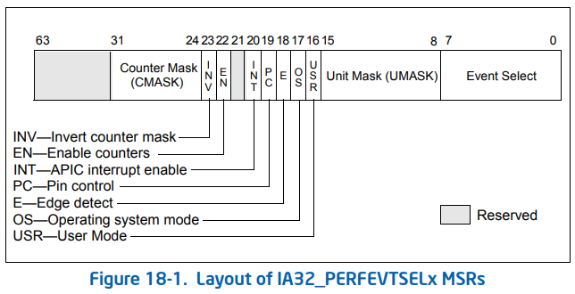

**Figure above:** Configuration register for individual counters. Of interest to us are the EN bit (mentioned in the previous subsection), the event selection fields, and the user mode bit. Note how the USR bit can only distinguish between ring 0 and ring 3. While rings 1 and 2 are still present in the CPU’s implementation today, no mainstream operating system has used them in over 30 years. The PMC, being a newer addition, acknowledges this reality in trying to simplify the control interface as much as possible. It is not clear if rings 1 and 2 are blind spots for PMCs or if they are covered under ring 0.

The **IA32_PERFEVENTSELx** are MSRs from *version 1* that are used to configure the monitored event of a certain counter, its enabled state and a few other things. We will not go into detail and instead only mention the fields that interest us right now (you can read about the rest in the Intel manual.) Note that the *x* in the MSR’s name stands for the counter number. If we have 4 counters, it takes values in the 0:3 range. The one that we will configure is IA32_PERFEVENTSEL0 (0x186). If you want to configure more than one counter, note that they have consecutive register number (i.e. 0x187, 0x188, etc.).

As for the register flags, those that are not mentioned in the following list should be left cleared:

- **EN** (enable flag) = **1** starts the counter
- **USR** (user mode flag) = **1** monitors only ring3 events
- **UMASK** (unit mask) = **??** depends on the monitored event (see chapter 19.2)
- **EVSEL** (event select) = **??** depends on the monitored event (see chapter 19.2)

Before actually writing in this register, we should verify that no one is currently using it. If this is indeed the case, we might also want to clear **IA32_PMC0** (0xc1). PMC0 is the actual counter that is associated to PERFEVENTSEL0.

```
$ sudo rdmsr -a 0x186
    0
$ sudo wrmsr -a 0xc1 0x00
$ sudo wrmsr -a 0x186 0x41????
```

For the next (and *final* task) we are going to monitor the number of L2 cache misses. Look for the **L2_RQSTS.MISS** event in table 19-3 or 19-11 (depending on CPU version id) in the Intel manual and set the last two bytes (the unit mask and event select) accordingly. If the operation is successful and the counters have started, you should start seeing non-zero values in the PMC0 register, increasing in subsequent reads.

### 4.4.5 Task E - Ring3 cache performance evaluation

As of now, we should be able to modify the **CR4** register with the kernel module, enable all counters in the **IA32_PERF_GLOBAL_CTRL** across all cores and start an **L2 cache miss** counter again, across all cores. What remains is putting everything into practice.

Take *mat_mul.c*. This program may be familiar from an ASC laboratory but, in case it isn’t, the gist of it is that when using the naive matrix multiplication algorithm (O(n^3)), the frequency with which each iterator varies can wildly affect the performance of the program. The reason behind this is (in)efficient use of the CPU cache. Take a look at the following snippet from the source and keep in mind that each matrix buffer is a continuous area in memory.

```
for (uint32_t i=0; i<N; ++i)             /* line   */
    for (uint32_t j=0; j<N; ++j)         /* column */
        for (uint32_t k=0; k<N; ++k)
            r[i*N + j] += m1[i*N + k] * m2[k*N + j];
```

What is the problem here? The problem is that i and k are multiplied with a large number N when updating a certain element. Thus, fast variations in these two indices will cause huge strides in accessed memory areas (larger than a cache line) and will cause unnecessary cache misses. So what are the best and worst configurations for the three fors? The best: i, k j. The worst: j, k, i. As we can see, the configurations that we will monitor in *mat_mul.c* do not coincide with the aforementioned two (so… not great, not terrible.) Even so, the difference in execution time and number of cache misses will still be significant.

Which brings us to the task at hand: using the **RDPMC** instruction, calculate the number of L2 cache misses for each of the two multiplications *without performing any context switches* (hint: look at [gcc extended asm](https://gcc.gnu.org/onlinedocs/gcc/Extended-Asm.html) and the following macro from *mat_mul.c*).

```
#define rdpmc(ecx, eax, edx)    \
    asm volatile (              \
        "rdpmc"                 \
        : "=a"(eax),            \
          "=d"(edx)             \
        : "c"(ecx))
```

A word of caution: remember that each logical core has its own PMC0 counter, so make sure to use taskset in order to set the CPU affinity of the process. If you don’t the process may be passed around different cores and the counter value becomes unreliable.

```
$ taskset 0x01 ./mat_mul 1024
```

### 4.4.6 Task F - Optimising *mat_mul.c*

Matrix multiplication has been used in a variety of applications such as machine learning and robotics. If you try increasing the size of the data, you may notice that the computation time increases rapidly. This makes the naive implementation of matrix multiplication not suitable for real-world applications, where the amount of data is huge and the runtime requirements are tight.

What would be the ways to optimise and accelerate this algorithm? What kind of metrics should you use to compare different implementations? How do you determine which implementation is better or worse? Here are the hints that you may follow. Feel free to apply other ideas if you have on your mind!

- You may use `perf` to help you analyse your techniques.
- Can the algorithm utilise caches more efficiently?
- Can the compiler help you?
- Can the computations be run in parallel? Would multithreading help?
- Hardware designers build modern processors with single instruction, multiple data (SIMD) support where you can compute a lot of data values at the same time at hardware level. Would SIMD instructions help here?
- Can you mix all/some of your ideas together to form a better technique?
- Which technique provides you the fastest matrix multiplication?

Use the points mentioned above to help in your analysis. Feel free to explore other questions as well. Explain your observations using measurements and graphs.